# Bivariate Maps

Diana Villasana Ocampo

## Bases de datos

El Secretariado Ejecutivo del Sistema Nacional de Seguridad Pública (SESNSP) es una entidad del gobierno de México encargada de coordinar y supervisar las políticas y estrategias de seguridad pública a nivel nacional. Su función principal es asegurar la colaboración efectiva entre las diversas instituciones de seguridad y justicia del país, así como recopilar y analizar datos sobre delitos y violencia para diseñar e implementar políticas de seguridad más efectivas y basadas en evidencia.

Se cargan las bases de datos que contienen el total de homicidios dolosos y feminicidios reportados a nivel municipal en el 2023. Esta base obtenida del Secretariado Ejecutivo del Sistema Nacional de Seguridad Pública esta sujeta a actualizaciones constantes, por lo que los datos del 2023 pueden ir cambiando. Aunado a esto, se consideran a las proyecciones de población a nivel municipal para el año 2023, elaboradas por el CONAPO.

```r
load(file = paste0(here::here(), "/Output/Homicidios.RData"))
load(file = paste0(here::here(), "/Output/Feminicidios.RData"))
load(file = paste0(here::here(), "/Output/Proyecciones_Poblacion.RData"))
```

Se integran las bases de datos de homicidios, feminicidios y población al 2023 en un data.frame `data`. De igual manera, una vez enlazadas las bases se calculan la tasa de homicidios dolosos por cada 10 000 habitantes en el municipio, y la tasa de feminicidios por cada 10 000 habitantes en el municipio.

```r
data <- poblacion %>%
         left_join(., Homicidios, by = c("CVE_MUN")) %>%
          left_join(., Feminicidios, by = c("CVE_MUN"))

# Se calculan la tasas de homicidos
data <- data %>%
         mutate(T_Homicidios = ifelse(is.na(.$Total_Homcidios/.$POB_TOT), 0, .$Total_Homcidios/.$POB_TOT * 10000),
                T_Feminicidio = ifelse(is.na(.$Total_Feminicidios/.$POB_TOT), 0, .$Total_Feminicidios/.$POB_TOT * 10000))
```

## Layers

Se leen los archivos GeoJSON que contienen datos geoespaciales utilizando la librería geojsonio. Los archivos contienen las capas de estados y municipios del Marco Geoestadístico Nacional para el año 2023.

- `geojsonio::geojson_read()`: Esta función lee un archivo GeoJSON y lo convierte en un objeto espacial en R.

```r
shape_estados <- geojsonio::geojson_read(paste0(here::here(),  "/Output/capa_estados_2023_json.geojson"), what = "sp")
shape_municipios <- geojsonio::geojson_read(paste0(here::here(), "/Output/capa_municipios_2023_json.geojson"), what = "sp")
```

La función `spChFIDs` cambia los IDs de las características en un objeto espacial. De esta manera cuando se requieran hacer calculos que modifiquen el data.frame; el orden de los polígonos no se mezclen entre ellos.

```r
shape_estados <- shape_estados %>%
                  sp::spChFIDs(., str_pad(.@data$CVE_ENT, 2, "left", pad = "0"))

shape_municipios <- shape_municipios %>%
                     sp::spChFIDs(., str_pad(.@data$CVE_MUN, 5, "left", pad = "0"))
```

Se lee el raster del Continuo de Elevaciones Mexicano (CEM), pero como paso previo se tuvo que transformar el archivo tio .tiff en .asc `--"gdal_translate(src_dataset = "../CEM/Nacional15_r30m.tif", dst_dataset = "../CEM/Nacional15_r30m.asc", of = "AAIGrid")"`.

- `as("SpatialPixelsDataFrame")`: Convierte el objeto raster en un `SpatialPixelsDataFrame`, una estructura adecuada para convertir a un marco de datos.
- `rasterToPoints(cem)`: Convierte los valores del raster en puntos, creando una matriz con columnas para las coordenadas `(x, y)` y los valores del raster.

```r
# read in raster of cem
cem <- raster("D:/CEM/Nacional15_r30m.asc") %>%
        # hide relief outside of states by masking with country borders
        # mask(shape_estados) %>%
         as("SpatialPixelsDataFrame") %>%
          as.data.frame()


cem_df <- as.data.frame(rasterToPoints(cem))
# Cambia los nombres de las columnas para usar con ggplot2
colnames(cem_df) <- c("x", "y", "value")

saveRDS(cem, file = paste0(here::here(), "Output/cem.RDS"))
```

### SpatialDataFrame

Se anexan el data.frame `data`, que contiene la tasa de homicidios y feminicidios al año 2023 en la capa de municipios.

```r
require(magrittr)
shape_municipios %<>%
  left_join(., data,  by = c("CVE_MUN"))
```

## Legend

Se crea la función `theme_map` que crea un tema personalizado por [Timo Grossenbacher](https://timogrossenbacher.ch/bivariate-maps-with-ggplot2-and-sf/). Este tema está específicamente diseñado para la visualización de mapas y establece varias propiedades estéticas, como colores, fuentes, y márgenes, para lograr un estilo cohesivo y profesional.

```r
# some constants
default_font_color <- "#4e4d47"
default_background_color <- "#f5f5f2"
default_font_family <- "Ubuntu Regular"
default_caption <- paste0("Map CC-BY-SA; Code: ",
                          "github.com/dvillasanao",
                          "\nAuthor: Diana Villasana",
                          " (@dvillasanao)",
                          "\nGeometries: Marco Geoestadístico Nacional 2023 and Continuo de Elevaciones Mexicano (CEM);",
                          " \nData: Secretariado Ejecutivo del Sistema Nacional de Seguridad Pública (SESNSP), 2024")
theme_map <- function(...) {
  theme_minimal() +
  theme(
    text = element_text(family = default_font_family,
                        color = default_font_color),
    # remove all axes
    axis.line = element_blank(),
    axis.text.x = element_blank(),
    axis.text.y = element_blank(),
    axis.ticks = element_blank(),
    # add a subtle grid
    panel.grid.major = element_line(color = "#dbdbd9", size = 0.2),
    panel.grid.minor = element_blank(),
    # background colors
    plot.background = element_rect(fill = default_background_color,
                                   color = NA),
    panel.background = element_rect(fill = default_background_color,
                                    color = NA),
    legend.background = element_rect(fill = default_background_color,
                                     color = NA),
    # borders and margins
    plot.margin = unit(c(.5, .5, .2, .5), "cm"),
    panel.border = element_blank(),
    panel.spacing = unit(c(-.1, 0.2, .2, 0.2), "cm"),
    # titles
    legend.title = element_text(size = 11),
    legend.text = element_text(size = 9, hjust = 0,
                               color = default_font_color),
    plot.title = element_text(size = 15, hjust = 0.5,
                              color = default_font_color),
    plot.subtitle = element_text(size = 10, hjust = 0.5,
                                 color = default_font_color,
                                 margin = margin(b = -0.1,
                                                 t = -0.1,
                                                 l = 2,
                                                 unit = "cm"),
                                 debug = F),
    # captions
    plot.caption = element_text(size = 7,
                                hjust = .5,
                                margin = margin(t = 0.2,
                                                b = 0,
                                                unit = "cm"),
                                color = "#939184"),
    ...
  )
}
```

## Univariate map

```r
require(BAMMtools)
require(tidyr)
require(purrr)

# define number of classes
no_classes <- 5

# extract quantiles
quantiles <- data %>%
              drop_na(T_Homicidios) %>%
               pull(T_Homicidios) %>%
                getJenksBreaks(., k = no_classes) %>%
                 as.vector() # to remove names of quantiles, so idx below is numeric

# here we create custom labels
labels <- imap_chr(quantiles, function(., idx){
  return(paste0(format(quantiles[idx], nsmall = 3, digits = 2),
                             "k",
                             " – ",
                             format(quantiles[idx + 1], nsmall = 3, digits = 2),
                             "k"))
})

# we need to remove the last label
# because that would be something like "478k - NA"
labels <- labels[1:length(labels) - 1]

# here we actually create a new
# variable on the dataset with the quantiles
shape_municipios %<>%
  mutate(homicidios_breaks = cut(Total_Homcidios,
                                  breaks = quantiles,
                                   labels = labels,
                                    include.lowest = T))
```

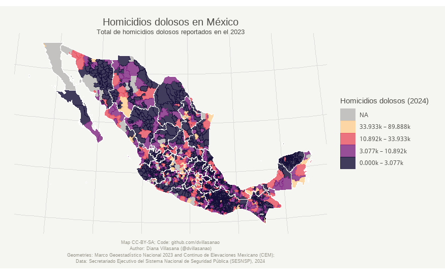

```r
ggplot() +
  # use thicker white stroke for borders
  geom_sf(data = st_as_sf(shape_municipios),
          aes(fill = homicidios_breaks,
              color = homicidios_breaks),
          linewidth = 0.002,
          size = 0.001) +
  geom_sf(data = st_as_sf(shape_estados),
          fill = "transparent",
          color = "white") +
  # use the Viridis color scale
  scale_fill_viridis(option = "magma",
                     name = "Homicidios dolosos (2024)",
                     alpha = 0.8, # make fill a bit brighter
                     begin = 0.1, # this option seems to be new (compared to 2016):
                     # with this we can truncate the color scale, so that extreme colors (very dark and very bright) are not used, which makes the map a bit more aesthetic
                     end = 0.9,
                     discrete = T, # discrete classes, thus guide_legend instead of _colorbar
                     direction = 1, # dark is lowest, yellow is highest
                     na.value = "#C4C2C1",
                     guide = guide_legend(keyheight = unit(5, units = "mm"),
                                          title.position = "top",
                                          reverse = T # display highest income on top
                                          )
                     ) +
  scale_color_viridis(option = "magma",
                     name = "Homicidios dolosos (2024)",
                     alpha = 0.8, # make fill a bit brighter
                     begin = 0.1, # this option seems to be new (compared to 2016):
                     # with this we can truncate the color scale, so that extreme colors (very dark and very bright) are not used, which makes the map a bit more aesthetic
                     end = 0.9,
                     discrete = T, # discrete classes, thus guide_legend instead of _colorbar
                     direction = 1, # dark is lowest, yellow is highest
                     na.value = "#C4C2C1",
                     guide = guide_legend(keyheight = unit(5, units = "mm"),
                                          title.position = "top",
                                          reverse = T # display highest on top
                                          )
                     ) +
  # add titles
  labs(x = NULL,
       y = NULL,
       title = "Homicidios dolosos en México",
       subtitle = "Total de homicidios dolosos reportados en el 2023",
       caption = default_caption) +
  # add theme
  theme_map()
```

## Bivariate map

**Clasificación bidimensional utilizando el método de Jenks:**

- `bi_class(., x = T_Homicidios, y = T_Feminicidio, style = "jenks", dim = 3)`: Esta función de la librería biscale clasifica las observaciones en el conjunto de datos shape_municipios basado en dos variables: T_Homicidios y T_Feminicidio.
- `x = T_Homicidios`: Especifica la primera variable para la clasificación.
- `y = T_Feminicidio`: Especifica la segunda variable para la clasificación.
- `style = "jenks"`: Utiliza el método de Jenks para determinar los puntos de corte óptimos.
- `dim = 3`: Especifica que las variables se clasificarán en una matriz 3x3, resultando en un total de 9 clases (3x3).

```r
require(biscale)
require(corrplot)
# create classes
shape_municipios <- shape_municipios %>%
                     bi_class(., x = T_Homicidios, y = T_Feminicidio, style = "jenks", dim = 3)
```

### Costumized pallete

Para evitar estar definiendo los colores de uno en uno.

- `setNames(..., nm = dims)`: Asigna los nombres de las dimensiones (etiquetas de las clases bivariadas) a los colores en la paleta.

```r
dims <- paste0(rep(seq(1:3), 3), "-", rep(seq(from = 1, to = 3), each = 3))

custom_pal <-setNames(object = colorRampPalette(pals::ocean.amp(100))(length(dims)),
                       nm = dims)

paleta <- bi_pal(pal = custom_pal, dim = 3, flip_axes = T, rotate_pal = T)
```

### Map

Siguiendo la misma estructura que el mapa anterior. Se utiliza como nueva alternativa `bi_scale_color()` que funciona del mismo modo que `bi_scale_fill()`.

```r
# create map
map <- ggplot() +
        geom_sf(data = st_as_sf(shape_municipios),
                mapping = aes(fill = bi_class,
                              color = bi_class),
                size = 0.1,
                show.legend = FALSE) +
        geom_sf(data = st_as_sf(shape_estados),
          fill = "transparent",
          color = "#C4C4C1") +
         bi_scale_fill(pal = custom_pal, dim = 3) +
         bi_scale_color(pal = custom_pal, dim = 3) +
          bi_theme() +
           theme(plot.title = element_text(size = 14),
                 plot.subtitle = element_text(size = 12))  +
          # add titles
          labs(x = NULL,
               y = NULL,
               title = "Tasa de delitos por homicidio y feminicidio en México",
               subtitle = "Tasa de homicidios y tasa de feminicidios en el 2023",
               caption = default_caption) +
          # add theme
          theme_map()
```

- La función `bi_legend()` del paquete `biscale`, crea una leyenda bivariada con la paleta de colores personalizada, especificando las etiquetas de los ejes y el tamaño del texto.
- Utilizando la función `draw_plot()` de la paquetería `cowplot` se coloca el mapa creado anteriormente y la leyenda en posiciones específicas dentro de la figura.
- finalPlot combina ambos elementos en una visualización final que se puede mostrar o guardar.

```r
legend <- bi_legend(pal = custom_pal,
                    dim = 3,
                    pad_color = 'transparent',
                    xlab = "% Homicidios",
                    ylab = "% Feminicidios",
                    size = 6)

# combine map with legend
finalPlot <- ggdraw() +
              draw_plot(map, 0, 0, 1, 1) +
               draw_plot(legend, x = 0.6, y = 0.5, width = 0.3, height =  0.3)
```

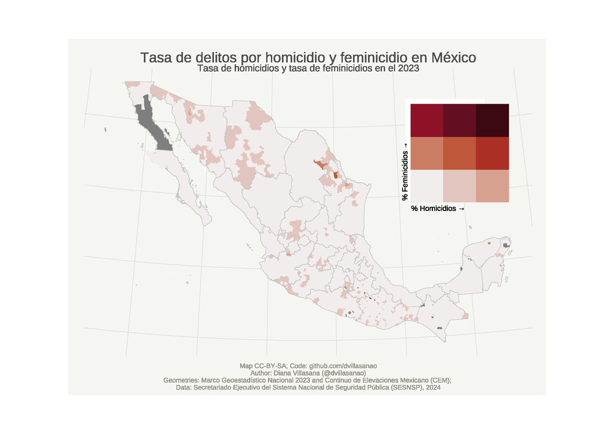

## Referencias

Chris-Prener/Biscale: Bivariate Mapping with Ggplot2, 2022.  
Bivariate Maps with Ggplot2 and Sf, 2019, Grossenbacher Timo. Retrieved June 2024, from https://timogrossenbacher.ch/author/timo/.  
Datos Abiertos de Incidencia Delictiva | Secretariado Ejecutivo Del Sistema Nacional de Seguridad Pública | Gobierno | Gob.Mx, 2024.  
Reconstrucción y Proyecciones de La Población de Los Municipios de México 1990-2040 | Consejo Nacional de Población | Gobierno | 2024.

## Librerías

**Librerías que se usaron en el trabajo**

```
 [1] "corrplot"    "biscale"     "knitr"       "purrr"       "tidyr"       "BAMMtools"   "ape"         "magrittr"    "stringr"
[10] "cowplot"     "viridis"     "viridisLite" "raster"      "spdplyr"     "rgdal"       "sp"          "geojsonio"   "sf"
[19] "ggplot2"     "dplyr"       "extrafont"   "showtext"    "showtextdb"  "sysfonts"
```

This work by **Diana Villasana Ocampo** is licensed under a [Creative Commons Attribution 4.0 International License](http://creativecommons.org/licenses/by/4.0/).